# Relationship between fertilization mode and other ecological traits in UK flora.

Ecological data on all the UK flora was gathered from the [ecoflora](http://ecoflora.org.uk/) and [plant atlas](https://www.brc.ac.uk/plantatlas/). As part of the preprocessing, species synonyms were solved and data was tided in to a ‘|’ (pipe symbol) separated dataframe where each observation (row) is a distinct species. Columns from the plant atlas were also copied in to the same dataframe.

First we load the dataframe

```r
df = read.delim('/home/sean/NERCflora/formFinal/finalFlat.csv', sep='|', na.strings=c("","NA","nan", "NaN", "Na"))
```

We factor some of the columns with ordinal nature

```r
df$myFertGen = factor(df$myFertGen, levels=c("generally self", "mixed", "generally cross"))
df$myHeavyMet <- factor(df$myHeavyMet, levels = c("none", "pseudometallophyte", "local metallophyte", "absolute metallophyte"))
df$myRarityCombined <- factor(df$myRarityCombined, levels = c("x", "r", "o", "s", "n"))
df$myLocalRarity <- factor(df$myLocalRarity, levels = c("scattered", "frequent", "dominant"))
```

The column myFertGen represents preprocessed data on fertilization mode for each species. Mostly this data was gathered directly from the ecoflora, but in some cases it was inferred from other ecological characteristics e.g. dioecious taxa are obligatory outcrossers. The ecoFlora most frequently labels species as “normally cross” and “normally self” so I have mirrored that choice in the categories I’ve assigned in the preprocessed data: “generally self”, “mixed”, “generally cross”.

The ecoflora often ambiguously gives more than one entry for data. So conflicts that don’t obviously infer “generaly cross” or “generally self” have been assigned “mixed”. Overall 1082 species were able to be assigned a fertilization mode in this way of the 3274 distinct species in the ecoflora.

```
 generally self           mixed generally cross
            272             364             446
```

As such the data in myFertGen is somewhat heuristic and wont strictly follow any quantitave rule such as *“every generally cross species has outcrossing rate between 0.6 and 0.8”*. Rather I hope the assignment in myFertGen is mostly accurate and have statistical significance such that models can be inferred from them.

To investigate possible ecological traits that could be linked with fertilization mode I used packages to generate decision trees. From those I inferred which other traits are linked to fertilization mode by how often they appear near the root of the tree.

We want to inspect how much intersection each column has with our data of interest. This way we can gather a list of useful columns.

```r
isect <- function(col){
  #returns intersection of non NaNs between col and myFert3
  return(length(col[!(is.na(col) | is.na(df$myFertGen))]))
}

intersections = data.frame(Column=character(), Intersection=integer())
for (i in names(df)){
  row = data.frame(Column = i, Intersection=isect(df[i]))
  intersections = rbind(intersections, row)
}
goodIsectCols = intersections[order(-intersections$Intersection)[1:150],]
goodIsectCols
```

|  | Column | Intersection |
| --- | --- | --- |
| 1 | species | 1082 |
| 190 | id | 1082 |
| 191 | genus | 1082 |
| 193 | myFert3 | 1082 |
| 194 | myFert5 | 1082 |
| 195 | myFertGen | 1082 |
| 158 | Carnivory | 1079 |
| 173 | Stems..1..woodiness | 1078 |
| 67 | Nutrition | 1077 |
| 106 | Leaf.shape..1..type | 1074 |

[output cut: 140 more lines]

```r
goodColVec = goodIsectCols$Column
goodColSimple = c()
for (col in goodColVec){
  if (!(class(df[col][1,1])=="factor" && length(unique(df[[col]])) > 20)){
    goodColSimple = append(goodColSimple, col)
  }
}
```

We look at the first few entries

```r
head(goodColSimple)
```

```
[1] "id"                  "myFert3"             "myFert5"             "myFertGen"           "Stems..1..woodiness" "Nutrition"
```

```r
goodColSimple = goodColSimple[5:length(goodColSimple)]
```

Obviously ID, myFert3 and myFert5 (which are older versions of my fert classifications) are not things we want to use to predict myFertGen, so I’ve discluded them.

We form the formula for our tree model

```r
formString = paste("myFertGen", goodColSimple[1], sep=" ~ ")
for (col in goodColSimple[2:length(goodColSimple)]){
  formString = paste(formString, col, sep = " + ")
}
form = as.formula(formString)
```

Now we form the trees, we can play with the complexity, setting cp=-1 means the algorithm doesn’t limit complexity.

```r
library(rpart)
suppressMessages(library(tidyverse))

#a small function for correctly sampling our data
sampleCustom <- function(df, fraction){
  #returns random subset by fraction of dataframe with fert info
  numRet = floor(fraction*NROW(subset(df, !is.na(myFertGen))))
  return(sample_n(subset(df, !is.na(myFert3)), numRet))
}

fraction = 0.7
treeFert = rpart(form, sampleCustom(df,fraction), cp=-1)
```

We can inspect the most important variables. The first column is a variable from the data and the second column is the arbitrary importantness of that variable in the tree algorithm

|  | treeFert$variable.importance[1:40] |
| --- | --- |
| Incompatibility.systems | 46.593496 |
| Seedbank.type | 31.846662 |
| myPlantAtPern1 | 27.323036 |
| SN.Index | 25.061260 |
| myPlantAtClone1 | 23.496970 |
| EW.Index | 18.824594 |
| Clonality..normal.state | 18.456383 |
| Annual.precipitation | 17.846394 |
| myEBergL | 17.521810 |
| Eastern.Limit | 17.324562 |

[output cut: 30 more lines]

The results are promising! Incompatibility systems is an obvious and uninteresting one, but it shows the ability of this method to pick out obvious correlating variables. It is important to bear in mind that a lot of the tree will be over fitting and it’s impossible to comprehend the tree as it stands currently. Thus it’s useful to re-sample the data and check what variables are persistently in the top 40. I’ll also record the variable importance as we go and order the final list by average importance.

```r
currInterestingVars = names(treeFert$variable.importance[1:40])
persistentInterestingVars = currInterestingVars
scoresDf = data.frame(var.name = c(), importance = c())

for (i in 1:5){
  treeFert = rpart(form, sampleCustom(df,fraction), cp=-1)
  interestingVarsVec = treeFert$variable.importance[1:40]

  currInterestingVars = names(interestingVarsVec)
  persistentInterestingVars = intersect(persistentInterestingVars, currInterestingVars)

  thisScoreDf = data.frame(var.name=names(interestingVarsVec), importance=unname(interestingVarsVec))
  scoresDf = rbind(scoresDf, thisScoreDf)

}

#shows persistently interesting varibles ordered by mean importance
suppressMessages(scoresDf %>% group_by(var.name) %>% summarise(mean.importance=mean(importance)) %>% filter(var.name %in% persistentInterestingVars) %>% arrange(-mean.importance))
```

| var.name | mean.importance |
| --- | --- |
| Incompatibility.systems | 55.473636 |
| Seedbank.type | 24.827029 |
| Annual.precipitation | 22.846880 |
| SN.Index | 22.056592 |
| January.mean.temperature | 21.279611 |
| Biome | 19.088312 |
| myPlantAtTjul | 19.076770 |
| Eastern.Limit | 18.311991 |
| Clonality..normal.state | 17.989439 |
| myPlantAtTjan | 17.957564 |

[output cut: 15 more lines]

Lets investigate the link in the variable *Clonality..normal.state* which is the clonality (type of vegetative spread) as given in the ecoflora. We’ll look at what the proportions of different clonalities are for different fertilization modes. The table “fractionNonClon” should be understood as *for species for which there is fertilization info and clonality info. for a given fertilization mode, what fraction have little/no vegetative spread*. It is what is represented graphically in the first figure by the teal coloured bar.

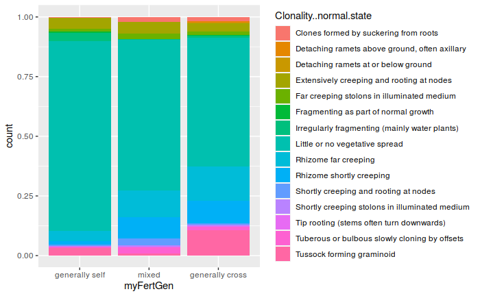

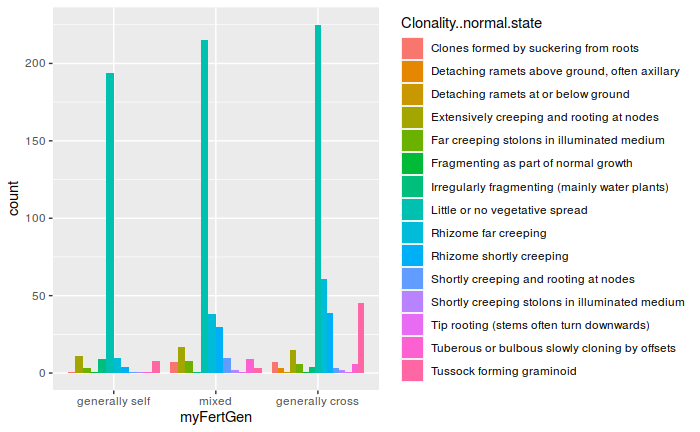

|  | fractionNonClon |
| --- | --- |
| generally self | 0.7950820 |
| mixed | 0.6304985 |
| generally cross | 0.5369928 |

```r
chisq.test(df$myPlantAtPern1, df$Clonality..normal.state)
```

```
Chi-squared approximation may be incorrect
```

```
    Pearson's Chi-squared test

data:  df$myPlantAtPern1 and df$Clonality..normal.state
X-squared = 383.85, df = 30, p-value < 2.2e-16
```

Now lets look at the variable “myPlantAtPern1” which is the perrenation (annual, biennial or perrenial) of species according to the plant atlas. The codes are a: annual, b: biennial, p: perrenial

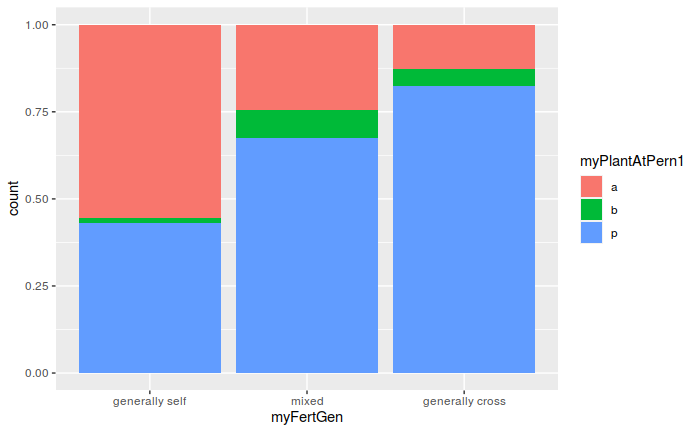

```r
df %>% filter(!is.na(myFertGen)) %>% filter(!is.na(myPlantAtPern1))%>% ggplot(aes(myFertGen, fill=myPlantAtPern1)) + geom_bar(position="Fill")
```

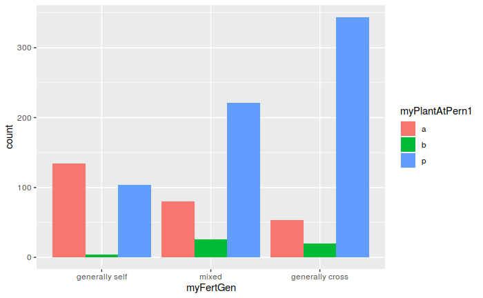

```r
df %>% filter(!is.na(myFertGen)) %>% filter(!is.na(myPlantAtPern1))%>% ggplot(aes(myFertGen, fill=myPlantAtPern1)) + geom_bar(position="Dodge")
```

```r
chisq.test(df$myPlantAtPern1, df$myFertGen)
```

```
    Pearson's Chi-squared test

data:  df$myPlantAtPern1 and df$myFertGen
X-squared = 150.4, df = 4, p-value < 2.2e-16
```

We see a clear pattern of outcrossing plants being proportionally more perennial than selfing plants. This can possibly be explained by annual plants requiring a greater reproductive guarantee as the current generation dies out. Again, the chi squared test gives positive results.

It is instructive to look at a less clear example. Seedbank.type, which is the nature of a species’ seed dormancy as given by the eco flora. It is not obvious that fertilization mode should correlate with this variable.

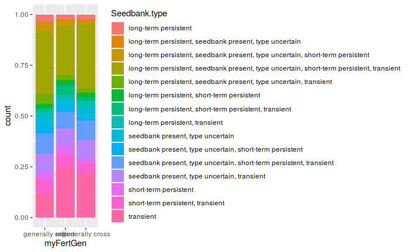

```r
df %>% filter(!is.na(myFertGen)) %>% filter(!is.na(Seedbank.type))%>% ggplot(aes(myFertGen, fill=Seedbank.type)) + geom_bar(position="Fill")
```

We face the difficulty of the quality of the data given in the ecoflora. Often for a single species and a single field it gives multiple entries. I have dealt with this by concatenating them in to a comma separated list. R treats each different list as a different factor, as it should, but this results in this data being unusable and it isn’t clear how to clean these multiple entries in to a single entry. Secondly, there isn’t a clear pattern across the fertilization modes. This variable was useful to the tree algorithm but it isn’t obvious to me.

Looking now at *Life.Form..normal.state* we see a clear pattern that with increasing outcrossing rate we have fractionally more [hemicryptophytes](https://en.wikipedia.org/wiki/Raunki%C3%A6r_plant_life-form#Hemicryptophytes) and fewer [therophytes](https://en.wikipedia.org/wiki/Raunki%C3%A6r_plant_life-form#Therophytes). This shines light on the trend seen with perrenation and I think could possibly be explained in a similar way.

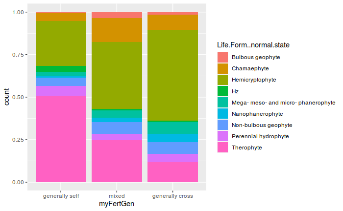

```r
df %>% filter(!is.na(myFertGen)) %>% filter(!is.na(Life.Form..normal.state))%>% ggplot(aes(myFertGen, fill=Life.Form..normal.state)) + geom_bar(position="Fill")
```

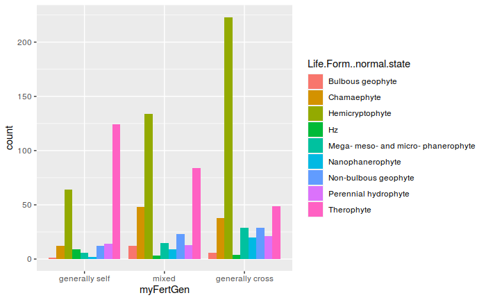

```r
df %>% filter(!is.na(myFertGen)) %>% filter(!is.na(Life.Form..normal.state))%>% ggplot(aes(myFertGen, fill=Life.Form..normal.state)) + geom_bar(position="Dodge")
```

```r
fractionHemicryptophyte =  prop.table(table( df$Life.Form..normal.state, df$myFertGen), 2)['Hemicryptophyte', ]
fractionTherophyte =  prop.table(table( df$Life.Form..normal.state, df$myFertGen), 2)['Therophyte', ]
as.data.frame(fractionHemicryptophyte)
```

|  | fractionHemicryptophyte |
| --- | --- |
| generally self | 0.2622951 |
| mixed | 0.3929619 |
| generally cross | 0.5322196 |

```r
as.data.frame(fractionTherophyte)
```

|  | fractionTherophyte |
| --- | --- |
| generally self | 0.5081967 |
| mixed | 0.2463343 |
| generally cross | 0.1169451 |

Now lets look at some continous variables, firstly myPlantAtRange, which is the number of 10x10km squares in which this species has been recored present in the British Isles. The first figure is a series of three boxplots illustrating the distribution of myPlantAtRange for each value of myFertGen. The second figure is a superposition of normalised probability density functions (estimated by R). One for each subset of the data by values of myFertGen. The second figure shows what fraction of the species are outcrossing, selfing or mixed for the whole range of myPlantAtRange. The grey lines show the overall fraction of species that are each value of myFertGen.

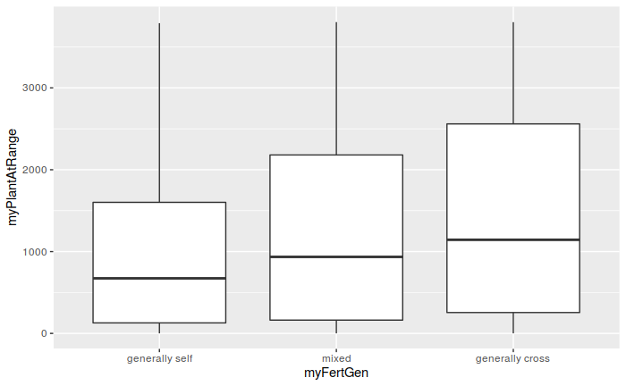

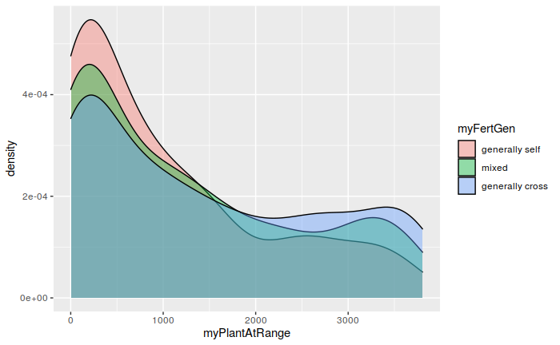

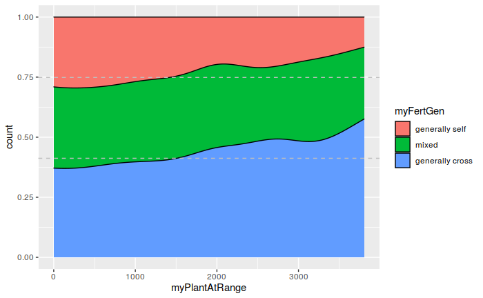

We see that outcrossing species have a generally greater range. In the 3rd figure we see that selfing species contribute ~30% of low range species but about 12% of highest range species, which are ubiquitous. Generally outcrossing species account for more than 55% of the ubiquitous species but only 41% of species overall.

This suggests that we should inspect the variable *myLocalRarity* which is a cleaned version of the variable *Typical.abundance.where.naturally.occuring* from the ecoflora. It has values “scattered”, “frequent” and “dominant” which describe how common a species is in regions where it is present.

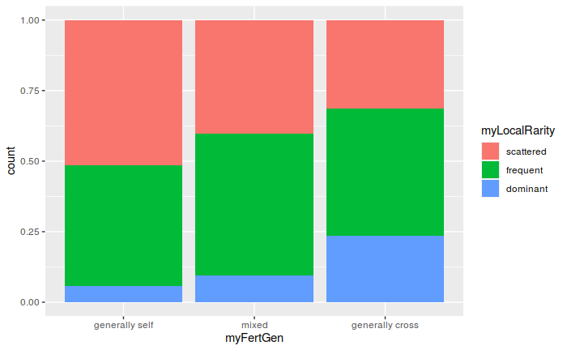

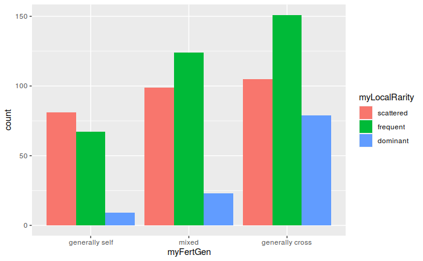

```
    Pearson's Chi-squared test

data:  df$myLocalRarity and df$myFertGen
X-squared = 43.642, df = 4, p-value = 7.613e-09
```

Indeed we see a strong correlation between fertilization mode and local rarity. Outcrossing species are more likely to be dominant and are less often scattered. We also see that generally selfing species are more likely to be scattered than frequent, whereas for mixed and generally outcrossing species, the opposite is true.

We now look at another continuous variable, SN.Index, which is an arbitrary scale of roughly how south (only at lands end corresponding to 0.0) or north (only in the Shetlands corresponding to 10.0) each species is. This is a strange one to be so highly ranked in our tree method.

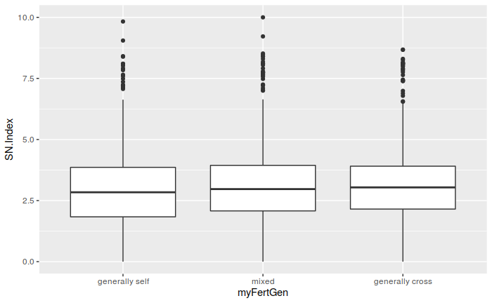

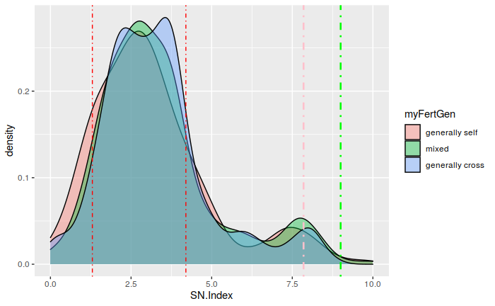

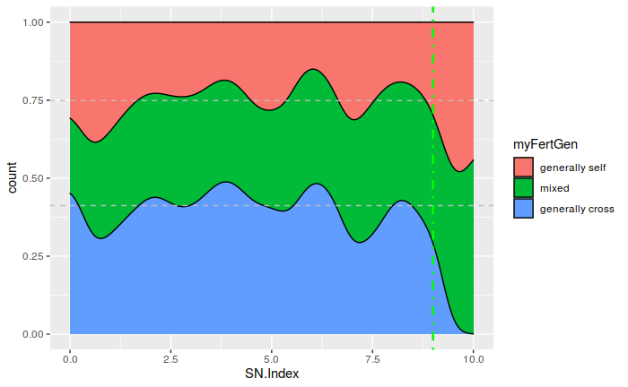

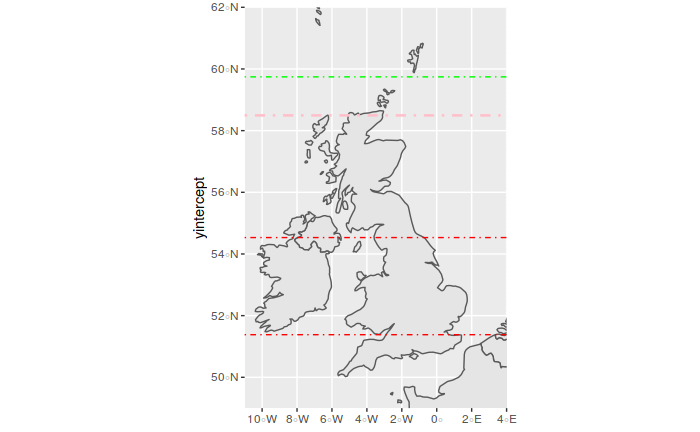

```
Std. dev. of NS Index by fert mode:
 self, mixed, cross
[1] 1.862299
[1] 1.855942
[1] 1.689405



Anova test.
              Df Sum Sq Mean Sq F value Pr(>F)
myFertGen      2      7   3.562   1.112  0.329
Residuals   1022   3273   3.202
2249 observations deleted due to missingness
```

The vertical lines on the plots, corresponding to horizontal lines on the map are simply features that I’m highlighting. Firstly we see a broad peak around 2.5 which represents the north south chunk of the British isles containing Ireland. In the third plot, we see that north of the green line (the Shetlands) becomes mostly mixed and self. But it should be noted this only corresponds to ~10 species. In the second plot we see a second peak around 7.8, indicated in pink, which corresponds to species generally found only at the north most coast of mainland Scotland. In the 3rd plot It is not clear if there is a pattern between SN.Index and fertilization mode and indeed by the ANOVA test we cannot reject the null hypothesis though we may infer that high island species are rarely crossers.

We now do a similar analysis on the east west index.

[figure not shown]

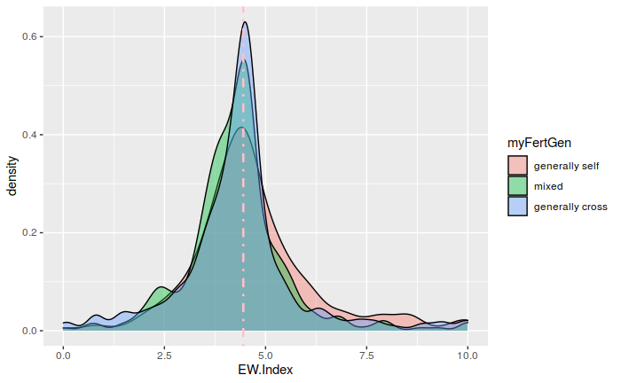

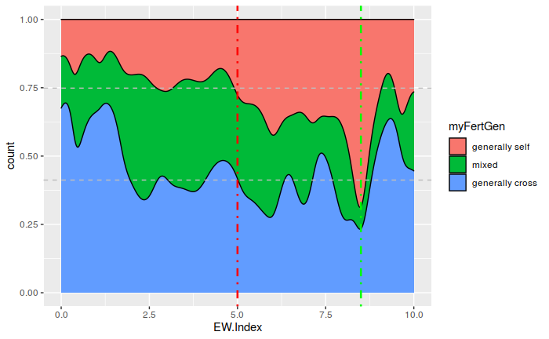

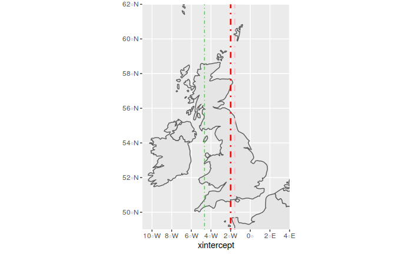

```
Std. dev. of EW Index by fert mode:
 self, mixed, cross
[1] 1.565862
[1] 1.274816
[1] 1.500711



Anova test.
              Df Sum Sq Mean Sq F value  Pr(>F)
myFertGen      2   23.7  11.857   5.679 0.00353 **
Residuals   1021 2131.6   2.088
---
Signif. codes:  0 ‘***’ 0.001 ‘**’ 0.01 ‘*’ 0.05 ‘.’ 0.1 ‘ ’ 1
2250 observations deleted due to missingness



Wilcox test on all possibles pairs from the three values of myFertGen.

    Wilcoxon rank sum test with continuity correction

data:  EW.Index by pairVals(myFertGen, "generally self", "mixed")
W = 49102, p-value = 0.002442
alternative hypothesis: true location shift is not equal to 0


    Wilcoxon rank sum test with continuity correction

data:  EW.Index by pairVals(myFertGen, "generally self", "generally cross")
W = 58716, p-value = 0.022
alternative hypothesis: true location shift is not equal to 0


    Wilcoxon rank sum test with continuity correction

data:  EW.Index by pairVals(myFertGen, "mixed", "generally cross")
W = 71322, p-value = 0.2913
alternative hypothesis: true location shift is not equal to 0




Testing significance of EW index > 5 VS Fert. Mode
EW Index > 5? (rows normalised)
                      FALSE      TRUE
  generally self  0.6923077 0.3076923
  mixed           0.8155620 0.1844380
  generally cross 0.8209302 0.1790698

    Pearson's Chi-squared test

data:  df$myFertGen and df$EWGreaterThan5
X-squared = 17.913, df = 2, p-value = 0.0001289
```

Bizarrely, the EW index only ranges across Britain, not including Ireland (this is as far as I can tell). It goes from East to West so 0 is Yarmouth and 10 is Penzance. There is a statistically significant fraction more selfers of index greater than 5, shown as west of the red line. This red line cuts off east England which has signifantly less rainfall. We perform an ANOVA which passes, rejecting the null hypothesis that all fertilization modes have the same mean EW index. We then investigate which pairs of groups by fertilization mode we can statistically differentiate by EW index by performing Wilconxon tests on the three pairings. We see that we can differentiate between selfers and both other modes but not between generally cross and mixed. This makes sense given what we observed with the EW distribution of selfers.

We can investigate the effect of precipitation now.

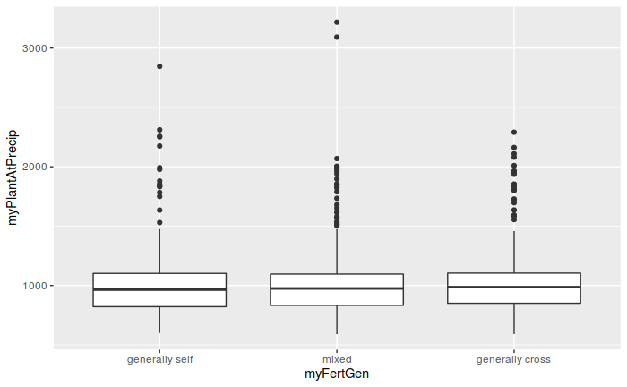

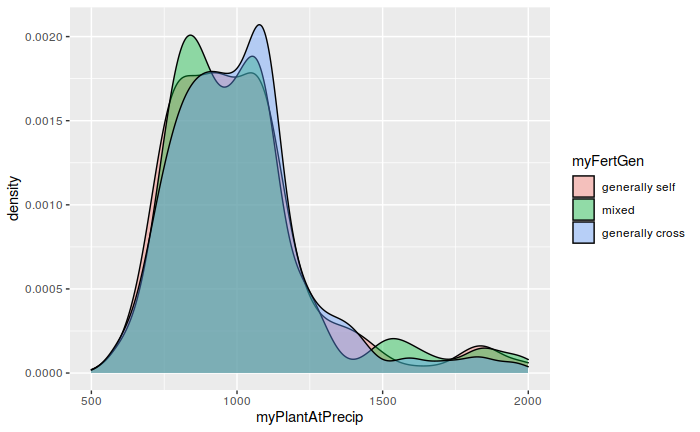

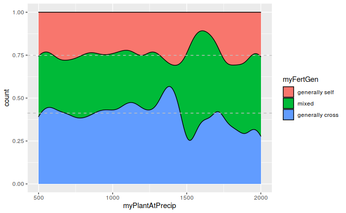

We must make these plots up to a 2000 on the myPlantAtPrecip axis as the data is too scarce beyond that. It is very hard to draw any correlation between fertilization mode and precipitation and indeed they seem uncorrelated.

We can run a few quick models to test further the hypothesis of an interaction between precipitation and EW index when predicting fertilization mode.

```r
lmPrecipVWest = lm(myPlantAtPrecip ~ EW.Index, data=df)
summary(lmPrecipVWest)
```

```
Call:
lm(formula = myPlantAtPrecip ~ EW.Index, data = df)

Residuals:
    Min      1Q  Median      3Q     Max
-467.13 -198.08  -73.97   72.61 2210.54

Coefficients:
            Estimate Std. Error t value Pr(>|t|)
(Intercept)  872.823     23.685  36.852  < 2e-16 ***
EW.Index      35.431      4.938   7.175 1.15e-12 ***
---
Signif. codes:  0 ‘***’ 0.001 ‘**’ 0.01 ‘*’ 0.05 ‘.’ 0.1 ‘ ’ 1

Residual standard error: 309 on 1461 degrees of freedom
  (1811 observations deleted due to missingness)
Multiple R-squared:  0.03404,   Adjusted R-squared:  0.03338
F-statistic: 51.48 on 1 and 1461 DF,  p-value: 1.146e-12
```

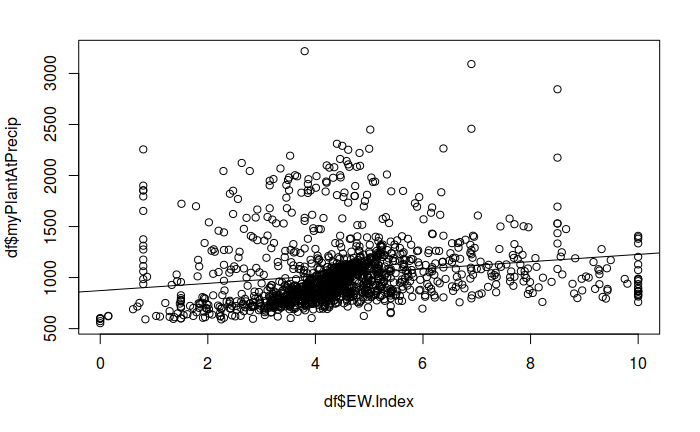

```r
plot(df$EW.Index, df$myPlantAtPrecip)
abline(lmPrecipVWest)
```

We see that westness and precipitation are positively correlated in this dataset, as could be predicted from knowledge of British weather.

Now we form a an interaction model.

```r
lmInt = lm(myFertGen ~ EW.Index * myPlantAtPrecip, data = df)
```

```
using type = "numeric" with a factor response will be ignored‘-’ not meaningful for factors
```

```r
lmInt
```

```
Call:
lm(formula = myFertGen ~ EW.Index * myPlantAtPrecip, data = df)

Coefficients:
             (Intercept)                  EW.Index           myPlantAtPrecip  EW.Index:myPlantAtPrecip
               2.231e+00                -6.969e-03                 1.466e-04                -3.667e-05
```

```r
lmIntNumeric = lm(as.numeric(myFertGen) ~ EW.Index * myPlantAtPrecip, data = df)
summary(lmIntNumeric)
```

```
Call:
lm(formula = as.numeric(myFertGen) ~ EW.Index * myPlantAtPrecip,
    data = df)

Residuals:
    Min      1Q  Median      3Q     Max
-1.4900 -0.3047 -0.1667  0.8073  1.0557

Coefficients:
                           Estimate Std. Error t value Pr(>|t|)
(Intercept)               2.231e+00  2.443e-01   9.133   <2e-16 ***
EW.Index                 -6.969e-03  5.381e-02  -0.130    0.897
myPlantAtPrecip           1.466e-04  2.313e-04   0.634    0.526
EW.Index:myPlantAtPrecip -3.667e-05  4.921e-05  -0.745    0.456
---
Signif. codes:  0 ‘***’ 0.001 ‘**’ 0.01 ‘*’ 0.05 ‘.’ 0.1 ‘ ’ 1

Residual standard error: 0.7952 on 955 degrees of freedom
  (2315 observations deleted due to missingness)
Multiple R-squared:  0.007418,  Adjusted R-squared:  0.0043
F-statistic: 2.379 on 3 and 955 DF,  p-value: 0.06835
```